# pop_gen_hw_1

Mrinal Vashisth

11/1/2019

# ALL CODE IN ONE PLACE

```r
# functions

wright_fisher_selective <- function(p, N, gens, w_11, w_12, w_22) {
  ac = c(p)
  for (x in 1:gens) {
    total_fitness = p * p * w_11 + 2 * p * (1 - p) * w_12 + ((1 - p) ^ 2) * w_22
    p_gf = (p * p * w_11 + p * (1 - p) * w_12)/total_fitness
    p = rbinom(1, 2 * N, p_gf)/(2 * N)
    ac = c(ac, p)
  }
  return(ac)
}

wright_fisher_sim <- function(p, N, gens) {
  answ = c(p)
  for (i in 1:gens){
    p_new = rbinom(1, 2*N, answ[length(answ)]) / (2*N)
    answ = c(answ, p_new)
  }
  return(answ)
}
```

```r
# part 2: chisq test
pp <- 0.775*0.775
qq <- 0.225*0.225
pq_2 <- 2*0.775*0.225
freqs <- c(pp*100,pq_2*100,qq*100)
 something <- data.frame("expected" = freqs, "observed" = c(60,35,10))

something_chisq<- chisq.test(something)

text_for <- 'We see that X-squared is:'

# part 3: wright fisher

jet = matlab.like2(100)

# Simultaing the drift for freq  0.5

n_iter = 250 # number of iterations
n_gen = 20
N = 100 # effective population size
p = 0.5

traj = sapply(1:n_iter, function(x) wright_fisher_sim(p, N, n_gen))

tr_df = as.data.frame(traj)
tr_df$generation = 1:nrow(tr_df)

plot_df_1 = melt(tr_df, id.vars='generation')

p1 <- ggplot(plot_df_1, aes(x=generation, y=value, group=variable)) + geom_line() +
  scale_y_continuous(limits=c(0, 1)) + ggtitle('a.) Simultaing the drift for freq  0.5')

# b.) Simultaing the drift for freq  0.1

n_iter = 250 # number of iterations
n_gen = 20
N = 100 # effective population size
p = 0.1

traj = sapply(1:n_iter, function(x) wright_fisher_sim(p, N, n_gen))

tr_df = as.data.frame(traj)
tr_df$generation = 1:nrow(tr_df)

plot_df_2 = melt(tr_df, id.vars='generation')

p2 <- ggplot(plot_df_2, aes(x=generation, y=value, group=variable)) + geom_line() +
  scale_y_continuous(limits=c(0, 1)) + ggtitle('b.) Simultaing the drift for freq  0.1')

#~~~~~~~~~~~~~~~~~~~~~~~~~~~~~~
# data.frame to be filled
wf_df <- data.frame()

# effective population sizes
sizes <- c(100,100)

# starting allele frequencies
starting_p <- c(0.5, 0.1)

# number of generations
n_gen <- 1000

# number of replicates per simulation
n_reps <- 20

# run the simulations
for(N in sizes){
  for(p in starting_p){
    p0 <- p
    for(j in 1:n_gen){
      X <- rbinom(n_reps, 2*N, p)
      p <- X / (2*N)
      rows <- data.frame(replicate = 1:n_reps, N = rep(N, n_reps),
                         gen = rep(j, n_reps), p0 = rep(p0, n_reps),
                         p = p)
      wf_df <- bind_rows(wf_df, rows)
    }
  }
}

# plot it up!
wf_df_plot <- ggplot(wf_df, aes(x = gen, y = p, group = replicate)) +
     geom_path(alpha = .5) + facet_grid(N ~ p0) + guides(colour=FALSE)


# part 4
#####################################################################
# Case 1) pp fitness = 1, pq fitness = 0.9, qq fitness = 0.8
#####################################################################
# Adding selection to model
n_iter = 100 # number of iterations
n_gen = 100
#####################################################################
w_11 = 1
w_12 = 0.9
w_22 = 0.8
N = 100000
p = 0.5

traj = sapply(1:n_iter, function(x) wright_fisher_selective(p, N, n_gen, w_11, w_12, w_22))

tr_df = as.data.frame(traj)
tr_df$generation = 1:nrow(tr_df)

plot_df = melt(tr_df, id.vars='generation')

subset_df <- plot_df %>% filter(generation == nrow(tr_df))

y1<- ggplot(plot_df, aes(x=generation, y=value, group=variable)) + geom_line()

z1 <- ggplot(subset_df, aes(x= variable, fill=generation)) + geom_histogram(stat='count', show.legend = FALSE) + ggtitle('Case 1) pp fitness = 1, pq fitness = 0.9, qq fitness = 0.8')

text1<- 'Case 1) pp fitness = 1, pq fitness = 0.9, qq fitness = 0.8, n_iter=100, generation = 100'
m1 <- mean(plot_df$value)


#####################################################################
# Case 2) pp fitness = 1, pq fitness = 1, qq fitness = 0.8
#####################################################################

# Adding selection to model
n_iter = 100 # number of iterations
n_gen = 100
#####################################################################
w_11 = 1
w_12 = 1
w_22 = 0.8
N = 100000
p = 0.5

traj = sapply(1:n_iter, function(x) wright_fisher_selective(p, N, n_gen, w_11, w_12, w_22))

tr_df = as.data.frame(traj)
tr_df$generation = 1:nrow(tr_df)

plot_df = melt(tr_df, id.vars='generation')

subset_df <- plot_df %>% filter(generation == nrow(tr_df))

y2<- ggplot(plot_df, aes(x=generation, y=value, group=variable)) + geom_line()

z2 <- ggplot(subset_df, aes(x= variable, fill=generation)) + geom_histogram(stat='count', show.legend = FALSE) + ggtitle('Case 2) pp fitness = 1, pq fitness = 1, qq fitness = 0.8')

text2<- 'Case 2) pp fitness = 1, pq fitness = 1, qq fitness = 0.8, n_iter=100, generations=100'
m2 <- mean(plot_df$value)

#####################################################################
# Case 3) pp fitness = 1, pq fitness = 0.9, qq fitness = 0.8
#####################################################################
# Adding selection to model
n_iter = 100 # number of iterations
n_gen = 500
#####################################################################
w_11 = 1
w_12 = 0.9
w_22 = 0.8
N = 100000
p = 0.5

traj = sapply(1:n_iter, function(x) wright_fisher_selective(p, N, n_gen, w_11, w_12, w_22))

tr_df = as.data.frame(traj)
tr_df$generation = 1:nrow(tr_df)

plot_df = melt(tr_df, id.vars='generation')

subset_df <- plot_df %>% filter(generation == nrow(tr_df))

y3<- ggplot(plot_df, aes(x=generation, y=value, group=variable)) + geom_line()

z3 <- ggplot(subset_df, aes(x= variable, fill=generation)) + geom_histogram(stat='count', show.legend = FALSE) + ggtitle('Case 3) pp fitness = 1, pq fitness = 0.9, qq fitness = 0.8')

text3<- 'Case 3) pp fitness = 1, pq fitness = 0.9, qq fitness = 0.8, n_iter=100, generations=500'
m3 <- mean(plot_df$value)


#####################################################################
# Case 4) pp fitness = 1, pq fitness = 1, qq fitness = 0.8
#####################################################################
# Adding selection to model
n_iter = 100 # number of iterations
n_gen = 500
#####################################################################
# Adding selection to model

w_11 = 1
w_12 = 1
w_22 = 0.8
N = 100000
p = 0.5

traj = sapply(1:n_iter, function(x) wright_fisher_selective(p, N, n_gen, w_11, w_12, w_22))

tr_df = as.data.frame(traj)
tr_df$generation = 1:nrow(tr_df)

plot_df = melt(tr_df, id.vars='generation')

subset_df <- plot_df %>% filter(generation == nrow(tr_df))

y4<- ggplot(plot_df, aes(x=generation, y=value, group=variable)) + geom_line()

z4 <- ggplot(subset_df, aes(x= variable)) + geom_histogram(stat='count', fill='green', show.legend = FALSE) + ggtitle('Case 4) pp fitness = 1, pq fitness = 1, qq fitness = 0.8')

text4<- 'Case 4) pp fitness = 1, pq fitness = 1, qq fitness = 0.8, n_iter=100, generations=500'
m4 <- mean(plot_df$value)


#####################################################################
# Case 5) pp fitness = 1, pq fitness = 0.9, qq fitness = 0.8
#####################################################################
# Adding selection to model
n_iter = 100 # number of iterations
n_gen = 1000
#####################################################################
w_11 = 1
w_12 = 0.9
w_22 = 0.8
N = 100000
p = 0.5

traj = sapply(1:n_iter, function(x) wright_fisher_selective(p, N, n_gen, w_11, w_12, w_22))

tr_df = as.data.frame(traj)
tr_df$generation = 1:nrow(tr_df)

plot_df = melt(tr_df, id.vars='generation')

subset_df <- plot_df %>% filter(generation == nrow(tr_df))

y5<- ggplot(plot_df, aes(x=generation, y=value, group=variable)) + geom_line()

z5 <- ggplot(subset_df, aes(x= variable))+ geom_histogram(stat='count', fill='green', show.legend = FALSE) + ggtitle('Case 5) pp fitness = 1, pq fitness = 0.9, qq fitness = 0.8')


text5<- 'Case 5) pp fitness = 1, pq fitness = 0.9, qq fitness = 0.8, n_iter=100, generations = 1000'
m5 <- mean(plot_df$value)


#####################################################################
# Case 6) pp fitness = 1, pq fitness = 1, qq fitness = 0.8
#####################################################################
# Adding selection to model
n_iter = 100 # number of iterations
n_gen = 1000
#####################################################################
# Adding selection to model

w_11 = 1
w_12 = 1
w_22 = 0.8
N = 100000
p = 0.5

traj = sapply(1:n_iter, function(x) wright_fisher_selective(p, N, n_gen, w_11, w_12, w_22))

tr_df = as.data.frame(traj)
tr_df$generation = 1:nrow(tr_df)

plot_df = melt(tr_df, id.vars='generation')

subset_df <- plot_df %>% filter(generation == nrow(tr_df))

y6<- ggplot(plot_df, aes(x=generation, y=value, group=variable)) + geom_line()

z6 <- ggplot(subset_df, aes(x= variable)) + geom_histogram(stat='count', fill='green', show.legend = FALSE) + ggtitle('Case 6) pp fitness = 1, pq fitness = 1, qq fitness = 0.8')

text6<- 'Case 6) pp fitness = 1, pq fitness = 1, qq fitness = 0.8, n_iter=100, generations = 1000'
m6 <- mean(plot_df$value)# Mean allele frequency in each simulation:


# part 5 code
# Adding selection to model

w_11 = 0.6
w_12 = 1
w_22 = 0.6
N = 1000
p = 0.5

traj = sapply(1:n_iter, function(x) wright_fisher_selective(p, N, n_gen, w_11, w_12, w_22))

tr_df = as.data.frame(traj)
tr_df$generation = 1:nrow(tr_df)

plot_df = melt(tr_df, id.vars='generation')

x1 <- ggplot(plot_df, aes(x=generation, y=value, group=variable)) + geom_line() +
  scale_y_continuous(limits=c(0, 1))

subset_df <- plot_df %>% filter(generation == nrow(tr_df))

text11<- 'w_11 = 0.6 | w_12 = 1 | w_22 = 0.6 | N = 1000 | p = 0.5 |'
g5 <- mean(plot_df$value)


# Adding selection to model

w_11 = 0.8
w_12 = 1
w_22 = 0.2
N = 1000
p = 0.5

traj = sapply(1:n_iter, function(x) wright_fisher_selective(p, N, n_gen, w_11, w_12, w_22))

tr_df = as.data.frame(traj)
tr_df$generation = 1:nrow(tr_df)

plot_df = melt(tr_df, id.vars='generation')

x2 <- ggplot(plot_df, aes(x=generation, y=value, group=variable)) + geom_line() +
  scale_y_continuous(limits=c(0, 1))

subset_df <- plot_df %>% filter(generation == nrow(tr_df))

text22<- 'w_11 = 0.8 | w_12 = 1 | w_22 = 0.2 | N = 1000 | p = 0.5'
g6 <- mean(plot_df$value)
```

# 1

AA:Aa:aa::65:25:10

Assuming incomplete dominance,

Total = (65+25+10)*2 = 200 Freq A = (130+25)/200 = 0.775 Freq a = 1-0.775 = 0.225

# 2

Let’s cross heterozygotes, assuming Mendelian dominance

|  | A | a |
| --- | --- | --- |
| A | AA | Aa |
| a | Aa | aa |

Chi squared,

|  | Dominant homozygote | Dominant heterozygote | Recessive homozygote |
| --- | --- | --- | --- |
| Expected |  |  |  |

```r
c(pp*100,pq_2*100,qq*100)
```

```
## [1] 60.0625 34.8750  5.0625
```

Chi_sq = sigma| [for {I} 0 to N] (obseved{i }– expected{i})/ expected{i}

```
## [1] "We see that X-squared is:"
```

```
## X-squared
##  1.497712
```

The critical value for the chi-square in this case is 5.991

We therefore ACCEPT THE NULL hypothesis, and conclude that there is NO SIGNIFICANT DIFFERENCE between the observed and expected frequencies of alleles. The frequencies of the three alleles at this locus are significantly similar between the two populations.

# 3

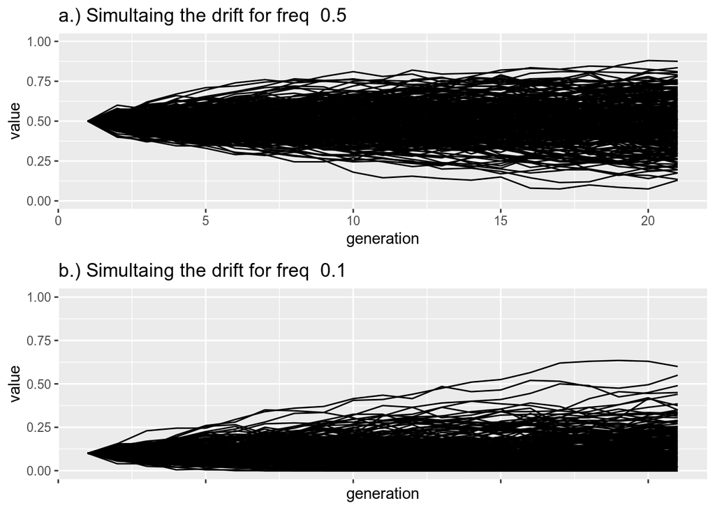

```r
ggarrange(p1, p2 + rremove("x.text"),
          ncol = 1, nrow = 2)
```

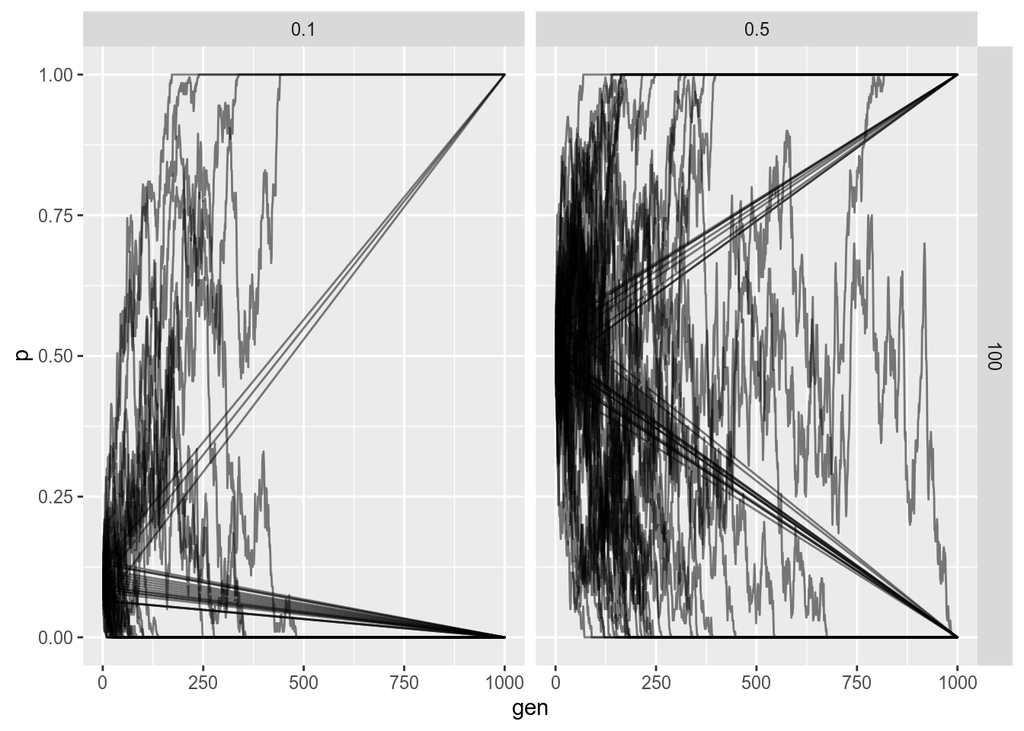

```
## [1] "For p_initial = 0.1"
```

```
##     FALSE      TRUE
## 0.2488388 0.6367550
```

```
## [1] "For p_initial = 0.5"
```

```
##     FALSE      TRUE
## 0.7511612 0.3632450
```

```r
wf_df_plot
```

We know that, the probability of fixation or loss of an allele in a pure drift Wright-Fisher model only depends on the previous count of the allele and the effective population size.

Intiutively probablities with higher initial frequencies are less likely to be lost for a big enough effective size of populations. As can be seen from the results, when intial p was high (0.5), p0 was 36%. As opposed to when p (0.1), where p0 reached 64%.

# 4

*Run the simulations three times*

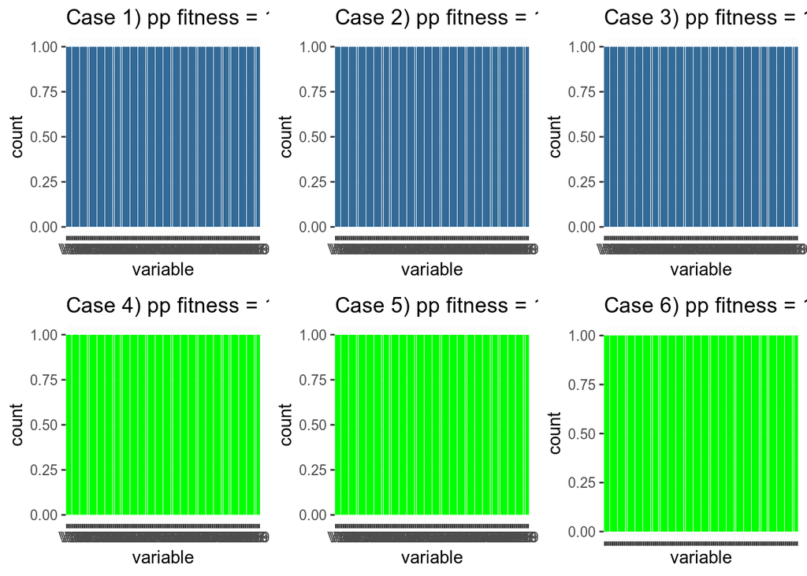

```r
ggarrange(z1, z2, z3, z4, z5, z6 + rremove("x.text"),
          ncol = 3, nrow = 2)
```

*What is the mean value of an allele frequency at the end of the simulation in each*

```
## [1] "Case 1) pp fitness = 1, pq fitness = 0.9, qq fitness = 0.8, n_iter=100, generation = 100"
```

```
## [1] 0.9343982
```

```
## [1] "Case 2) pp fitness = 1, pq fitness = 1, qq fitness = 0.8, n_iter=100, generations=100"
```

```
## [1] 0.8581544
```

```
## [1] "Case 3) pp fitness = 1, pq fitness = 0.9, qq fitness = 0.8, n_iter=100, generations=500"
```

```
## [1] 0.9867721
```

```
## [1] "Case 4) pp fitness = 1, pq fitness = 1, qq fitness = 0.8, n_iter=100, generations=500"
```

```
## [1] 0.9548659
```

```
## [1] "Case 5) pp fitness = 1, pq fitness = 0.9, qq fitness = 0.8, n_iter=100, generations = 1000"
```

```
## [1] 0.9933814
```

```
## [1] "Case 6) pp fitness = 1, pq fitness = 1, qq fitness = 0.8, n_iter=100, generations = 1000"
```

```
## [1] 0.9740581
```

*Does the allele frequency reach a plateau in each of the two cases? Why?*

Yes, as we can see that in each of the two cases we have a plateau.

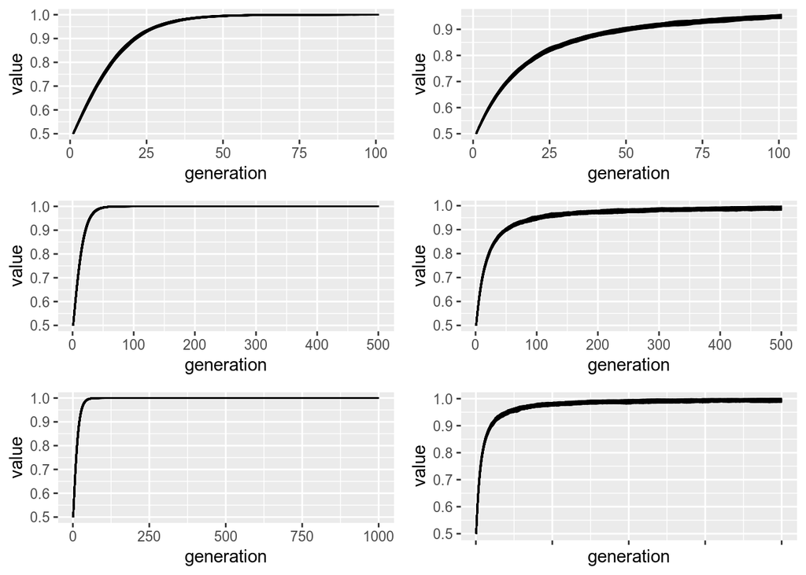

```r
ggarrange(y1, y2, y3, y4, y5, y6 + rremove("x.text"),
          ncol = 2, nrow = 3)
```

We see that a species that consists of one large panmictic population reaches an adaptive plateau by mass selection, and it ends up with evolutionary stagnation.

# 5

*simulations for the following fitness scores*

```
## [1] "w_11 = 0.6 | w_12 = 1 | w_22 = 0.6 | N = 1000 | p = 0.5 |"
```

```
## [1] 0.500199
```

```
## [1] "w_11 = 0.8 | w_12 = 1 | w_22 = 0.2 | N = 1000 | p = 0.5"
```

```
## [1] 0.7998898
```

```r
fitnesses <- c(g5, g6)
mt_fitness <- sapply(fitnesses, function(x) p * p * w_11 + 2 * p * (1 - p) * w_12 + ((1 - p) ^ 2) * w_22)

mt_fitness
```

```
## [1] 0.75 0.75
```

*for each combination of fitness scores. Do the values differ and why?*

Clearly the values of p_mean are different but the mean total fitness remains the same. One hint comes from the parameters themselves. If we look at second combination, for example, nw_pp, and nw_qq have seperate fitnessess and clearly nw_pp (0.8) > nw_qq (0.2). We can see an exaggerated difference for N = 1000 and p =0.5 as clearly nw_pp is preferred over nw_qq.

While in the first case where nw_pp (0.6) is the same as nw_qq there is no such preference.

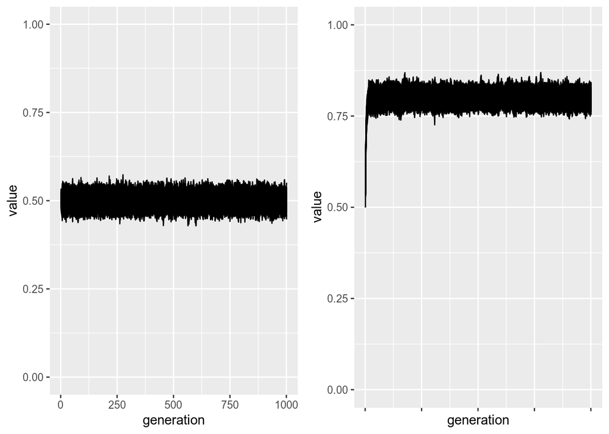

```r
ggarrange(x1, x2 + rremove("x.text"),
          ncol = 2, nrow = 1)
```